# Analysis

```python
#loading data set and import libraries
import pandas as pd
import matplotlib.pyplot as plt
%matplotlib inline

df = pd.read_csv('twitter_archive_master.csv')
```

After having prepared our data set, let's have a look on most favorite dog breeds on WeRateDogs Twitter Account.

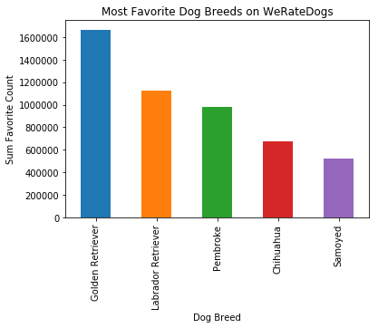

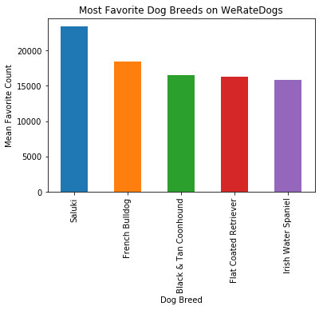

```python
#https://stackoverflow.com/questions/11244514/modify-tick-label-text

fig, ax = plt.subplots()

labels = ['Golden Retriever', 'Labrador Retriever', 'Pembroke', 'Chihuahua', 'Samoyed']
df[df['p1_dog']==True].groupby(df['p1'])['favorite_count'].sum().sort_values(ascending=False)[0:5].plot(kind='bar')
plt.xlabel('Dog Breed')
ax.set_xticklabels(labels)
plt.ylabel('Sum Favorite Count')
plt.title('Most Favorite Dog Breeds on WeRateDogs');

fig, ax = plt.subplots()

labels2 = ['Saluki', 'French Bulldog', 'Black & Tan Coonhound', 'Flat Coated Retriever', 'Irish Water Spaniel']
df[df['p1_dog']==True].groupby(df['p1'])['favorite_count'].mean().sort_values(ascending=False)[0:5].plot(kind='bar')
plt.xlabel('Dog Breed')
ax.set_xticklabels(labels2)
plt.ylabel('Mean Favorite Count')
plt.title('Most Favorite Dog Breeds on WeRateDogs');
```

```python
df[df['p1_dog']==True].groupby(df['p1']).count()['favorite_count'].sort_values(ascending=False)[0:5]
```

```
p1
golden_retriever      150
Labrador_retriever    100
Pembroke               88
Chihuahua              81
pug                    57
Name: favorite_count, dtype: int64
```

Bar chart indicates that so far Golden Retriever receives the most favorite count and is thus, the most favore dog breed on WeRateDogs. Golden Retriever is followed by the also very popular breeds of Labrador Retriever and Pembroke. On the other hand, it is not surprising to see this situation as Golden Retriever also account for the most tweets (150), followed by Labrador Retriever (100) and Pembroke (88).

When we calculate the mean counts , the situation changes drastically. From this calculation , the data indicates that Saluki, French Bulldong and Black T Tan Coonhound are the most popular dog breeds on WeRateDogs.

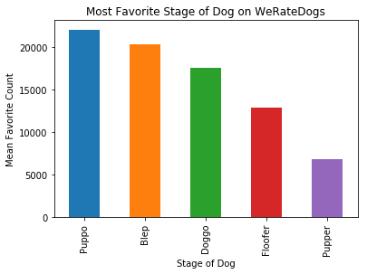

```python
labels = ['Puppo', 'Blep', 'Doggo', 'Floofer', 'Pupper']
fig, ax = plt.subplots()
df.groupby(['stage_of_dog']).favorite_count.mean().sort_values(ascending=False).plot(kind='bar')

plt.xlabel('Stage of Dog')
ax.set_xticklabels(labels)
plt.ylabel('Mean Favorite Count')
plt.title('Most Favorite Stage of Dog on WeRateDogs');
```

Our data set indicate that depending on the Stage of a Dog, a post seem to receive different mean favorite counts. The bar chart indicates that Puppo, Blep and Doggos seem to receive more favorites than Floffer and Pupper do. In Average, Puppo and Blep receive more than 20'000 like counts per tweet. Doggos account for about 17500 favorite counts per tweat, wheareas Floofer only receive about 12800 favorite counts and Pupper only about 6800.

[figure not shown]

```python
df['ratio'] = df['numerator'] / df['denominator']
labels = ['Pomeranian', 'Saluki', 'Tibetian Mastiff', 'Briard', 'Border Terrier']
fig, ax = plt.subplots()

df[df['p1_dog']==True].groupby(df['p1'])['ratio'].mean().sort_values(ascending=False)[0:5].plot(kind='bar')

plt.xlabel('Best Rated Dog Breeds by WeRateDogs')
ax.set_xticklabels(labels)
plt.ylabel('Mean Ratio (Numerator/Denominator)')
plt.title('Most Favorite Stage of Dog on WeRateDogs');
```

In comparison to our public statistics, it is interesting to see that different breeds are rated the highest from WeRateDogs itself. Here, Pomernian, Saluki, Tibetian Mastiff, Briand and Border Terier achieve the highest scores. This is a very interesting fact, considering Saluki being also among the populars in the previous analyses. It indicates that the popularity of dog breeds are different among the WeRateDogs audiance and the channel owners.

Submitted By:Avinash, Date: Arpil 5,2020